```python
import numpy as np
import matplotlib
import matplotlib.pyplot as plt
import scipy
from scipy import stats
import math
import statistics


#this sets the size of the plot to something useful
plt.rcParams["figure.figsize"] = (15,10)
```

# Homework 4

The purpose of this homework is to get used to plotting and examining subsets of data. In the next lab we will have 25 million data points. And big instruments produce data at even more fantastic rates—our telescope in western Australia produces a billion data values per second, and we're hoping to upgrade it to produce at least an order of magnitude more.

You don't want to plot millions to billions of points on a plot, it will look like a blob and take forever. So we need to practice looking at subsets of the data.

## Problem 0: some fake data to mess with

So let's start by making some fake background data.

First, let's make a time axis that goes from 0 to 100 π in 1e5 steps

```python
t = np.linspace(0,np.pi*100,np.int(1e5))
```

Then an offset sinusoid

```python
N = 10+np.sin(t)
```

Then some random background data whose mean and variance depend on N

```python
bkgd = stats.norm.rvs(size=np.int(1e5))*np.sqrt(N)+N
```

Now this is small enough at only 100,000 points that you can plot it, but it is messy and not very informative.

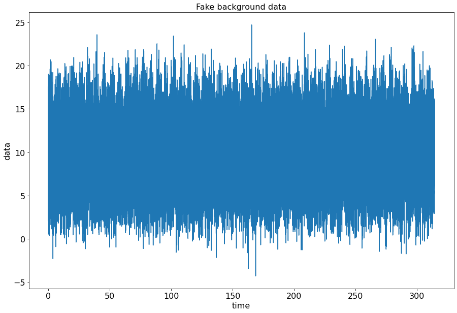

```python
plt.plot(t,bkgd)
plt.title('Fake background data', fontsize = 16)
plt.tick_params(labelsize = 16)
plt.xlabel('time', fontsize=16)
plt.ylabel('data', fontsize=16)
plt.show()
```

## Problem 1: subsets of data

The idea here is to plot small portions of the data. In python this is often called array slicing, but in other languages it has no special terminology. Your goal is to figure out how to make the following plots:

#### **1a) Make a scatter plot (not a line plot) of the first 1000 data points.**

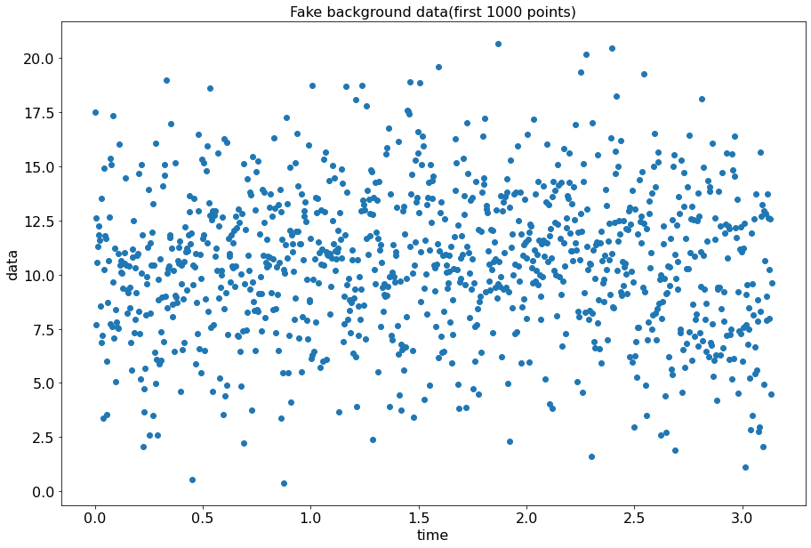

```python
t_thousand = t[0:999]
bkgd_thousand = bkgd[0:999]
plt.plot(t_thousand,bkgd_thousand, 'o')
plt.title('Fake background data(first 1000 points)', fontsize = 16)
plt.tick_params(labelsize = 16)
plt.xlabel('time', fontsize=16)
plt.ylabel('data', fontsize=16)
plt.show()
```

#### **1b) Generalize your code so you can make a plot of any X contiguous points (e.g. 2000 points starting at point 500), and produce an example plot of a set of data somethere in the middle of your array.**

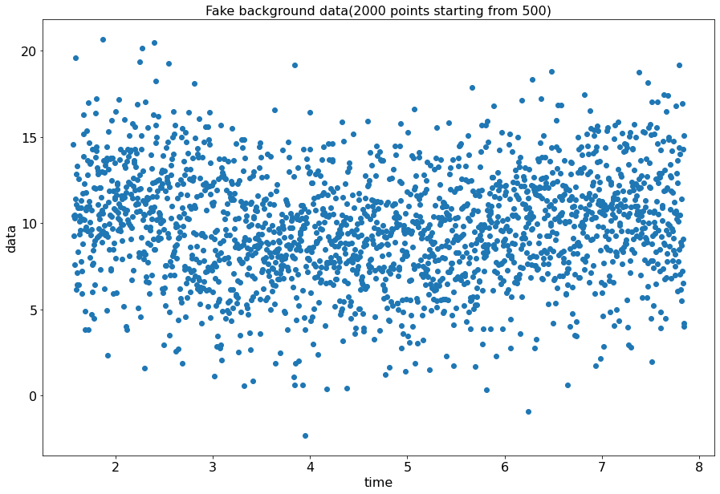

```python
STARTING_POINT = 500 #the point you want to start with
NUM_OF_POINTS = 2000 #the number of data points you want


t_thousand = t[STARTING_POINT - 1: STARTING_POINT + NUM_OF_POINTS -1]
bkgd_thousand = bkgd[STARTING_POINT - 1: STARTING_POINT + NUM_OF_POINTS -1]
plt.plot(t_thousand,bkgd_thousand, 'o')
plt.title('Fake background data(' + str(NUM_OF_POINTS) + ' points starting from ' + str(STARTING_POINT) + ')', fontsize = 16)
plt.tick_params(labelsize = 16)
plt.xlabel('time', fontsize=16)
plt.ylabel('data', fontsize=16)
plt.show()
```

#### **1c) Sometimes you want to sample the data, such as plotting every 100th point. Make a plot of the full data range, but only every 100th point.**

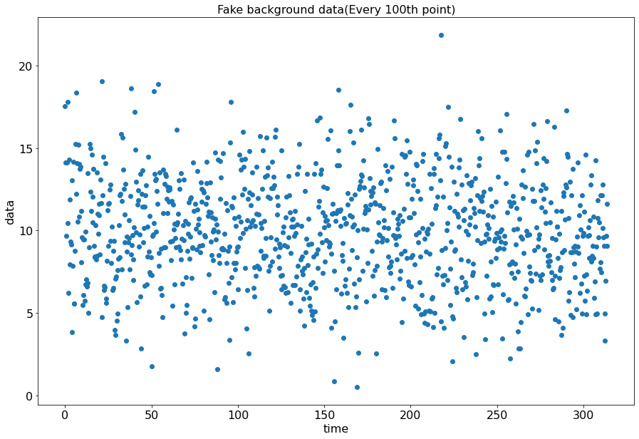

```python
t_100th = t[0:len(t) - 1:100]
bkgd_100th = bkgd[0:len(t) - 1:100]
plt.plot(t_100th,bkgd_100th, 'o')
plt.title('Fake background data(Every 100th point)', fontsize = 16)
plt.tick_params(labelsize = 16)
plt.xlabel('time', fontsize=16)
plt.ylabel('data', fontsize=16)
plt.show()
```

## Problem 2: density

Now you can make a scatter plot of just a 100,000 points, so you might try it to see what it looks like. But particularly in the central areas the points all overlap into just a blob, and this just gets worse as the number of points goes up. What is better is to plot the density of the points. There are several ways of doing this, but a 2D histogram plot is the easiest (plt.hist2d() in python and histogram2() in MatLab).

#### **2a) Make a 2d histogram plot. Read about options, and play with binsize so it is useful (too large a bin and everything washes out, too small and the sample noise dominates). Make sure you use a colorbar.**

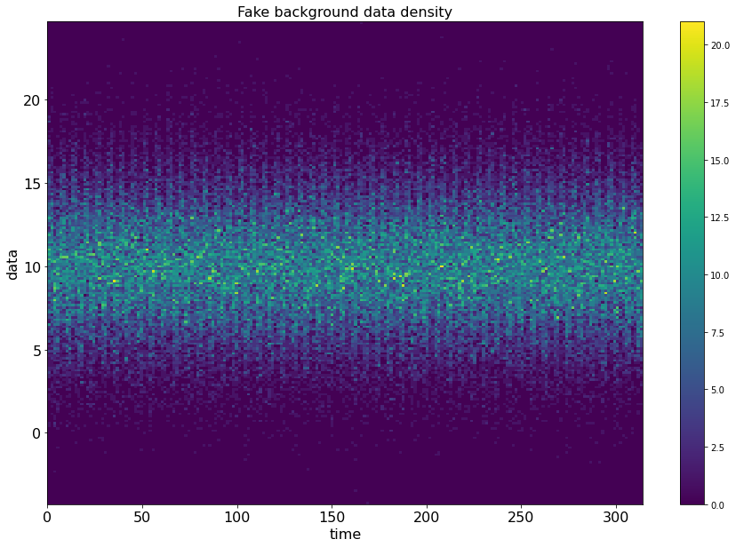

```python
hist_plot = plt.hist2d(t,bkgd, bins=200)
plt.colorbar(hist_plot[3])
plt.title('Fake background data density', fontsize = 16)
plt.tick_params(labelsize = 16)
plt.xlabel('time', fontsize=16)
plt.ylabel('data', fontsize=16)
plt.show()
```

#### **2b) Clearly explain what is being plotted in your plot (e.g. what does each color mean?)**

The plot represents the density of our data points at different time and different value of data, indicated by the color. The brighter the color, the highter density of data points at that place. The number on the color bar gives the number of data points at the location on the graph with that color.

## Problem 3: folding

Now if you have a periodic signal, it is possible to fold the data stream at that period to make the pattern clearer.

#### **3a) Make an new time variable that folds at a period of 2π (the modulo operator is your friend, variably expressed as mod(), %, or rem()). Then make a scatter plot of all your data, but now folded. (Reminder, for more data you'd never actually want to plot all the points.)**

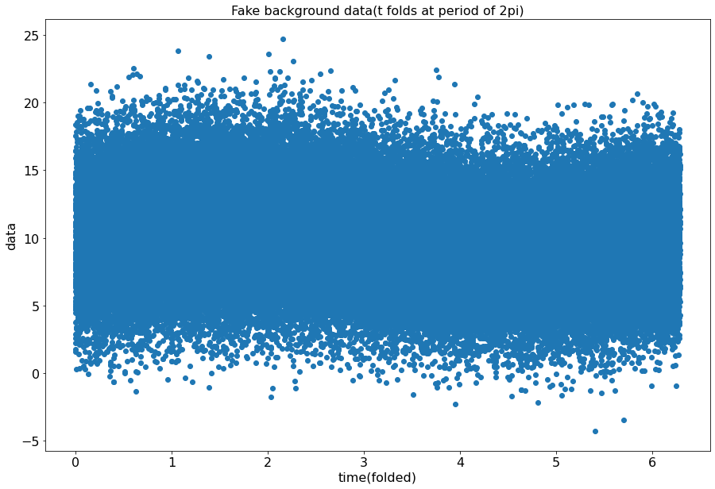

```python
t_folded = t % (2*np.pi)
plt.plot(t_folded,bkgd, 'o')
plt.title('Fake background data(t folds at period of 2pi)', fontsize = 16)
plt.tick_params(labelsize = 16)
plt.xlabel('time(folded)', fontsize=16)
plt.ylabel('data', fontsize=16)
plt.show()
```

#### **3b) Make a 2D histogram plot of your folded data.**

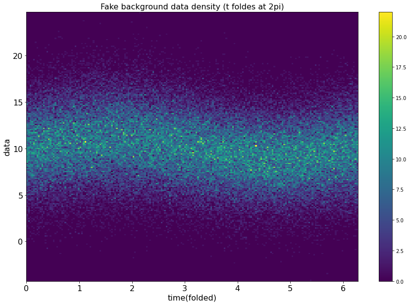

```python
hist_plot = plt.hist2d(t_folded,bkgd, bins=200)
plt.colorbar(hist_plot[3])
plt.title('Fake background data density (t foldes at 2pi)', fontsize = 16)
plt.tick_params(labelsize = 16)
plt.xlabel('time(folded)', fontsize=16)
plt.ylabel('data', fontsize=16)
plt.show()
```

```python
!jupyter nbconvert --to html hw4_notebook.ipynb
```

```
[NbConvertApp] Converting notebook hw4_notebook.ipynb to html
[NbConvertApp] Writing 1120886 bytes to hw4_notebook.html
```